# 03_Exclusion

Chiara Draxler

29 3 2022

#Introduction for working code:

0. Download the Code from Github. The new downloaded folder hc_switch_cccu-main contains the R project, Rmd Code, created data frames, knitted Html Code, Figures as .pdf and.jpg, Preregistered synthetic Code, and a folder to store the downloaded RData called RData.

Name the folder appropriately (when downloading the code from GitHub the folder will be hc_switch_cccu-main).

1. Download data from https://www.icpsr.umich.edu/web/DSDR/studies/37067/datadocumentation

Attention! The downloaded project from GitHub does not contain any data files!

–> Click on Download, then select R, then follow the login –> store data in the folder specific to the R project in an extra sub-folder called RData (i.e., hc_switch_cccu-main - > RData). If you downloaded the code from GitHub, the RData folder will be already in the hc_switch_cccu-main projects folder.

–> Within the RData folder store data for wave 1 in DS0001, for wave 2 in DS0002 and so on (i.e., hc_switch_cccu-main - > RData -> DS0001 ). If you downloaded the code from GitHub, the relevant folders will be already there.

–> name the Rdata files according to the wave:

Wave 1: 37067-0001-Data (i.e., hc_switch_cccu-main - > RData -> DS0001 -> 37067-0001-Data.rda )

Wave 2: 37067-0002-Data (i.e., hc_switch_cccu-main - > RData -> DS0002 -> 37067-0002-Data.rda )

Wave 3: 37067-0003-Data (i.e., hc_switch_cccu-main - > RData -> DS0003 -> 37067-0003-Data.rda )

Wave 4: 37067-0004-Data (i.e., hc_switch_cccu-main - > RData -> DS0004 -> 37067-0004-Data.rda )

–> attention to the .rda ending when loading the data into R!

2. make sure to install all relevant packages before running the code!

All relevant packages and versions can be seen in the section “Analyses”

3. run the code according to the defined order beginning with 01_ (or 0 if you want to have a look at the synthetic data) and ending with 09_ so that all data frames are created appropriately
4. Run the Code :)

#1. Load Data

```r
load("cccu_complete1.RData")
```

#2. Load Packages

```r
library(dplyr)
library(formr)
```

```r
library(ggplot2)
```

#3. Full Dataset

```r
nrow(cccu_complete1) #timepoints
```

```
## [1] 12081
```

```r
length(unique(cccu_complete1$CASEID)) #women
```

```
## [1] 4634
```

##3.1 Exclude t4 from df (bc. not necessary)

```r
cccu_complete1 <- cccu_complete1 %>%
  filter(WAVE != "t4")
```

# 4 Building columns that indicate exclusion from df

1 = yes

## 4.1 Missing Main Predictor: HC

Dont exclude current IUD & non-hormonal

```r
table(cccu_complete1$hc)
```

```
##
##         hc     non_hc IUD&non_hc
##       3965       5282        992
```

```r
table(is.na(cccu_complete1$hc))
```

```
##
## FALSE
## 10239
```

```r
cccu_complete1 <- cccu_complete1 %>%
 mutate(exclusion_missing_predHC = ifelse(is.na(hc), 1, 0))

table(cccu_complete1$exclusion_missing_predHC)
```

```
##
##     0
## 10239
```

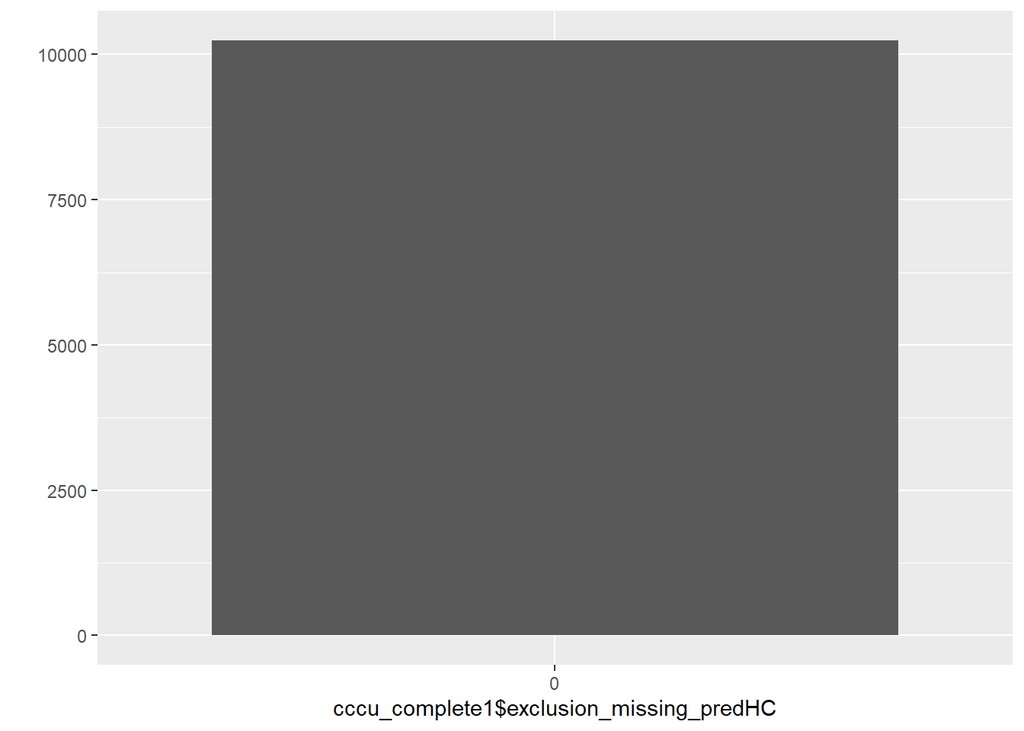

```r
cccu_complete1$exclusion_missing_predHC <- as.factor(cccu_complete1$exclusion_missing_predHC)
qplot(cccu_complete1$exclusion_missing_predHC)
```

```r
x = cccu_complete1 %>%
  select(hc, exclusion_missing_predHC)
```

## 4.2 Missing Main Predictor: Satisfaction with HC

```r
table(cccu_complete1$contra_satis)
```

```
##
##    1    2    3    4
##  155  447 2232 3798
```

```r
table(is.na(cccu_complete1$contra_satis))
```

```
##
## FALSE  TRUE
##  6632  3607
```

```r
crosstabs( ~ is.na(contra_satis) + WAVE, data = cccu_complete1)
```

```
##                    WAVE
## is.na(contra_satis)   t1   t2   t3   t4
##               FALSE 3118 2039 1475    0
##               TRUE  1516 1168  923    0
```

```r
cccu_complete1 <- cccu_complete1 %>%
 mutate(exclusion_missing_pred_contra_satis = ifelse(is.na(contra_satis), 1, 0))

table(cccu_complete1$exclusion_missing_pred_contra_satis)
```

```
##
##    0    1
## 6632 3607
```

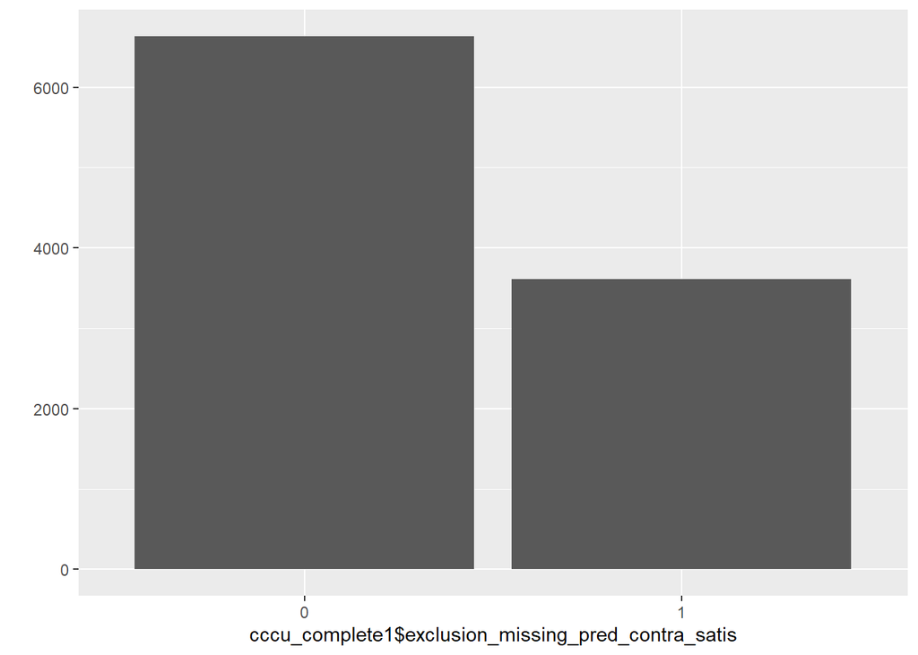

```r
cccu_complete1$exclusion_missing_pred_contra_satis <- as.factor(cccu_complete1$exclusion_missing_pred_contra_satis)
qplot(cccu_complete1$exclusion_missing_pred_contra_satis)
```

```r
x = cccu_complete1 %>%
  select(contra_satis, exclusion_missing_pred_contra_satis)
```

## 4.3 Missing Main Predictor: Sex Freq & Sex Sat

```r
#sex freq
table(cccu_complete1$sex_freq)
```

```
##
##   No sex or once        2-5 times       6-10 times 11 or more times
##             2872             3538             2274             1429
```

```r
table(is.na(cccu_complete1$sex_freq))
```

```
##
## FALSE  TRUE
## 10113   126
```

```r
cccu_complete1 <- cccu_complete1 %>%
 mutate(exclusion_missing_pred_sex_freq= ifelse(is.na(sex_freq), 1, 0))

table(cccu_complete1$exclusion_missing_pred_sex_freq)
```

```
##
##     0     1
## 10113   126
```

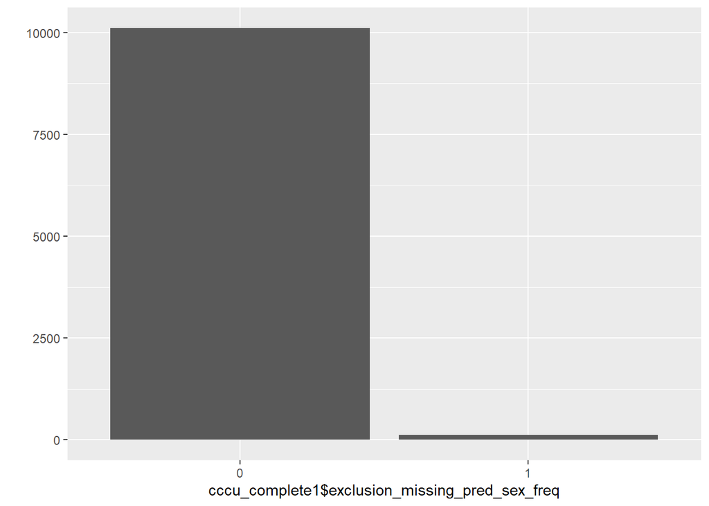

```r
cccu_complete1$exclusion_missing_pred_sex_freq <- as.factor(cccu_complete1$exclusion_missing_pred_sex_freq)
qplot(cccu_complete1$exclusion_missing_pred_sex_freq)
```

```r
x = cccu_complete1 %>%
  select(sex_freq, exclusion_missing_pred_sex_freq)

#sex_sat
table(cccu_complete1$sexual_satisfaction)
```

```
##
##    1    2    3    4    5    6
##  183  292  635 1432 2121 3956
```

```r
table(is.na(cccu_complete1$sexual_satisfaction))
```

```
##
## FALSE  TRUE
##  8619  1620
```

```r
cccu_complete1 <- cccu_complete1 %>%
 mutate(exclusion_missing_pred_sex_sat= ifelse(is.na(sexual_satisfaction), 1, 0))

crosstabs( ~ is.na(sexual_satisfaction) + rel_dur_factor, data = cccu_complete1)
```

```
##                           rel_dur_factor
## is.na(sexual_satisfaction) Single 0q-25q 26q-50q 51q-75q 76q-100q
##                      FALSE   1835   1733    1728    1712     1611
##                      TRUE    1551     21      14      17       17
```

```r
table(cccu_complete1$exclusion_missing_pred_sex_sat)#high missingness
```

```
##
##    0    1
## 8619 1620
```

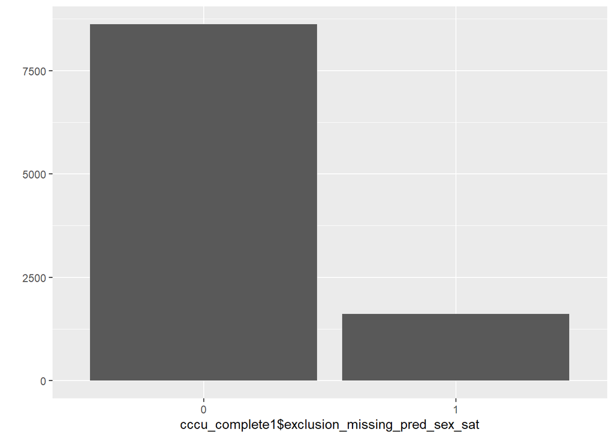

```r
cccu_complete1$exclusion_missing_pred_sex_sat <- as.factor(cccu_complete1$exclusion_missing_pred_sex_sat)
qplot(cccu_complete1$exclusion_missing_pred_sex_sat)
```

```r
x = cccu_complete1 %>%
  select(sexual_satisfaction, exclusion_missing_pred_sex_sat)
```

## 4.4 Missing Selection Predictors

```r
#Age
cccu_complete1 <- cccu_complete1 %>%
 mutate(exclusion_missing_selection_age = as.factor(ifelse(is.na(AGE),1,0)))

table(is.na(cccu_complete1$AGE))
```

```
##
## FALSE
## 10239
```

```r
table(cccu_complete1$exclusion_missing_selection_age)
```

```
##
##     0
## 10239
```

```r
#Degree
cccu_complete1 <- cccu_complete1 %>%
 mutate(exclusion_missing_selection_degree = as.factor(ifelse(is.na(DEGREE_recode),1,0)))

table(is.na(cccu_complete1$DEGREE_recode))
```

```
##
## FALSE
## 10239
```

```r
table(cccu_complete1$exclusion_missing_selection_degree)
```

```
##
##     0
## 10239
```

```r
#Povrate
cccu_complete1 <- cccu_complete1 %>%
 mutate(exclusion_missing_selection_povrate= as.factor(ifelse(is.na(POVRATE),1,0)))

table(is.na(cccu_complete1$POVRATE))
```

```
##
## FALSE
## 10239
```

```r
table(cccu_complete1$exclusion_missing_selection_povrate)
```

```
##
##     0
## 10239
```

```r
#Healthproblems
cccu_complete1 <- cccu_complete1 %>%
 mutate(exclusion_missing_selection_healthprb= as.factor(ifelse(is.na(HLTHPROB_recode),1,0)))

table(is.na(cccu_complete1$HLTHPROB_recode))
```

```
##
## FALSE  TRUE
##  9663   576
```

```r
table(cccu_complete1$exclusion_missing_selection_healthprb)#high missings
```

```
##
##    0    1
## 9663  576
```

```r
#Med Problems
cccu_complete1 <- cccu_complete1 %>%
 mutate(exclusion_missing_selection_medprob= as.factor(ifelse(is.na(MEDPROB_recode),1,0)))

table(is.na(cccu_complete1$MEDPROB_recode))
```

```
##
## FALSE
## 10239
```

```r
table(cccu_complete1$exclusion_missing_selection_medprob)
```

```
##
##     0
## 10239
```

```r
#Gaps in insurance
cccu_complete1 <- cccu_complete1 %>%
 mutate(exclusion_missing_selection_gapins= as.factor(ifelse(is.na(GAPINS_recode),1,0)))

table(is.na(cccu_complete1$GAPINS_recode))
```

```
##
## FALSE  TRUE
## 10151    88
```

```r
table(cccu_complete1$exclusion_missing_selection_gapins)#missings
```

```
##
##     0     1
## 10151    88
```

```r
#Type of insurance
cccu_complete1 <- cccu_complete1 %>%
 mutate(exclusion_missing_selection_typeins= as.factor(ifelse(is.na(TYPEINS_recode),1,0)))

table(is.na(cccu_complete1$TYPEINS_recode))
```

```
##
## FALSE  TRUE
## 10151    88
```

```r
table(cccu_complete1$exclusion_missing_selection_typeins)#missings
```

```
##
##     0     1
## 10151    88
```

```r
#N Kids at T1
cccu_complete1 <- cccu_complete1 %>%
 mutate(exclusion_missing_selection_nkids= as.factor(ifelse(is.na(NKIDS_t1),1,0)))

table(is.na(cccu_complete1$NKIDS_t1))
```

```
##
## FALSE  TRUE
## 10210    29
```

```r
table(cccu_complete1$exclusion_missing_selection_nkids)#missings
```

```
##
##     0     1
## 10210    29
```

```r
#pregnant between waves
cccu_complete1 <- cccu_complete1 %>%
 mutate(exclusion_missing_selection_preg_bet_waves= as.factor(ifelse(is.na(pregnant_between_waves),1,0)))

table(is.na(cccu_complete1$pregnant_between_waves))
```

```
##
## FALSE  TRUE
## 10203    36
```

```r
table(cccu_complete1$exclusion_missing_selection_preg_bet_waves)#missings
```

```
##
##     0     1
## 10203    36
```

```r
#had baby between waves
cccu_complete1 <- cccu_complete1 %>%
 mutate(exclusion_missing_selection_baby_bet_waves= as.factor(ifelse(is.na(had_baby_between_waves),1,0)))

table(is.na(cccu_complete1$had_baby_between_waves))
```

```
##
## FALSE  TRUE
## 10203    36
```

```r
table(cccu_complete1$exclusion_missing_selection_baby_bet_waves)#missings
```

```
##
##     0     1
## 10203    36
```

```r
#Feel about pregnancy
cccu_complete1 <- cccu_complete1 %>%
 mutate(exclusion_missing_selection_feelpg= as.factor(ifelse(is.na(FEELPG_recode),1,0)))

table(is.na(cccu_complete1$FEELPG_recode))
```

```
##
## FALSE  TRUE
##  9861   378
```

```r
table(cccu_complete1$exclusion_missing_selection_feelpg)#high missings
```

```
##
##    0    1
## 9861  378
```

```r
#Avoidance of pregnancy
cccu_complete1 <- cccu_complete1 %>%
 mutate(exclusion_missing_selection_avoid= as.factor(ifelse(is.na(Avoid_r),1,0)))

table(is.na(cccu_complete1$Avoid_r))
```

```
##
## FALSE  TRUE
##  9866   373
```

```r
table(cccu_complete1$exclusion_missing_selection_avoid)#high missings
```

```
##
##    0    1
## 9866  373
```

```r
#Relationship duration
cccu_complete1 <- cccu_complete1 %>%
 mutate(exclusion_missing_selection_reldur= as.factor(ifelse(is.na(rel_dur_factor),1,0)))

table(is.na(cccu_complete1$rel_dur_factor))
```

```
##
## FALSE
## 10239
```

```r
table(cccu_complete1$exclusion_missing_selection_reldur)
```

```
##
##     0
## 10239
```

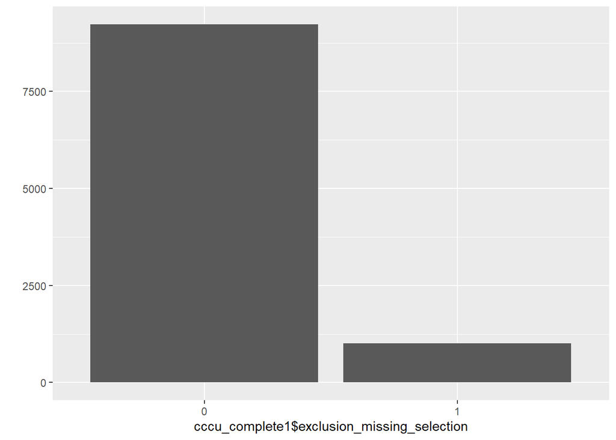

```r
#complete exclusion for all selection variables
cccu_complete1 <- cccu_complete1 %>% mutate(exclusion_missing_selection = as.factor(ifelse(is.na(AGE) | is.na(DEGREE_recode) | is.na(POVRATE)| is.na(HLTHPROB_recode) | is.na(MEDPROB_recode)| is.na(GAPINS_recode) | is.na(TYPEINS_recode) | is.na(NKIDS_t1) |is.na(pregnant_between_waves) | is.na(had_baby_between_waves) | is.na(FEELPG_recode) | is.na(Avoid_r) | is.na(rel_dur_factor), 1, 0)))

qplot(cccu_complete1$exclusion_missing_selection)
```

```r
table(cccu_complete1$exclusion_missing_selection)
```

```
##
##    0    1
## 9228 1011
```

```r
x = cccu_complete1 %>%
  select(exclusion_missing_selection, exclusion_missing_selection_age, exclusion_missing_selection_degree, exclusion_missing_selection_povrate, exclusion_missing_selection_healthprb, exclusion_missing_selection_medprob, exclusion_missing_selection_gapins, exclusion_missing_selection_typeins, exclusion_missing_selection_nkids, exclusion_missing_selection_preg_bet_waves, exclusion_missing_selection_baby_bet_waves, exclusion_missing_selection_feelpg, exclusion_missing_selection_avoid, exclusion_missing_selection_reldur)
```

## 4.5 Missing Outcome (switch)

Dont exclude next IUD & non-hormonal

```r
table(cccu_complete1$switch)
```

```
##
##    0    1
## 6450  997
```

```r
table(is.na(cccu_complete1$switch))#high missingness
```

```
##
## FALSE  TRUE
##  7447  2792
```

```r
crosstabs( ~ is.na(switch) + WAVE, data = cccu_complete1)
```

```
##              WAVE
## is.na(switch)   t1   t2   t3   t4
##         FALSE 3207 2398 1842    0
##         TRUE  1427  809  556    0
```

```r
cccu_complete1 %>% select(CASEID, WAVE, hc, hc_next, switch) %>% View()

cccu_complete1 <- cccu_complete1 %>%
 mutate(exclusion_missing_outc_switch= ifelse(is.na(switch), 1, 0))

table(cccu_complete1$exclusion_missing_outc_switch)
```

```
##
##    0    1
## 7447 2792
```

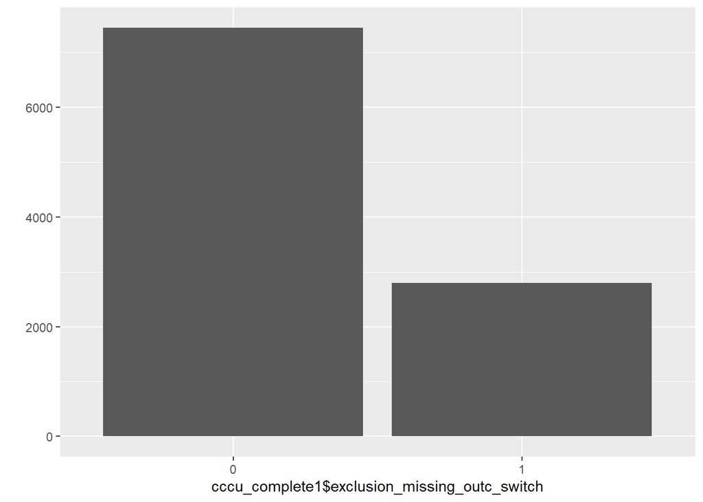

```r
cccu_complete1$exclusion_missing_outc_switch <- as.factor(cccu_complete1$exclusion_missing_outc_switch)

qplot(cccu_complete1$exclusion_missing_outc_switch)
```

```r
x = cccu_complete1 %>%
  select(switch, exclusion_missing_outc_switch)
```

## 4.6 Emergency contraception

```r
#overview

table(cccu_complete1$EC_recode)
```

```
##
##   No  Yes
## 4188   73
```

```r
#create column that indicates if used EC

cccu_complete1 <- cccu_complete1 %>%
  mutate(exclusion_used_EC = ifelse(is.na(EC_recode), 0,
                                    ifelse(EC_recode == "No", 0,
                                           ifelse(EC_recode == "Yes", 1, NA))))

table(cccu_complete1$exclusion_used_EC)
```

```
##
##     0     1
## 10166    73
```

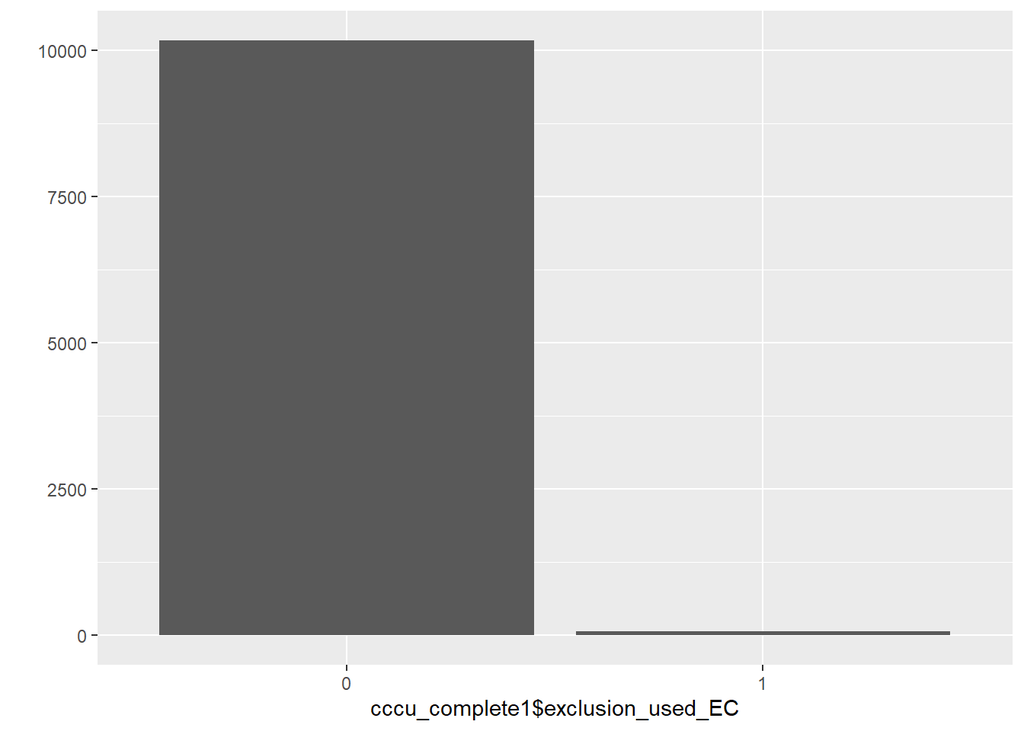

```r
cccu_complete1$exclusion_used_EC<- as.factor(cccu_complete1$exclusion_used_EC)
qplot(cccu_complete1$exclusion_used_EC)
```

## 4.7 IUD & Non-Hormonal

```r
table(cccu_complete1$hc)
```

```
##
##         hc     non_hc IUD&non_hc
##       3965       5282        992
```

```r
table(cccu_complete1$IUD)
```

```
##
##  (0) No (1) Yes
##    9215    1024
```

```r
#IUD & non-hormonal
cccu_complete1 <- cccu_complete1 %>%
 mutate(exclusion_IUD = ifelse(hc == "IUD&non_hc", 1,0))

table(cccu_complete1$IUD)
```

```
##
##  (0) No (1) Yes
##    9215    1024
```

```r
table(cccu_complete1$exclusion_IUD)
```

```
##
##    0    1
## 9247  992
```

```r
table(is.na(cccu_complete1$exclusion_IUD))
```

```
##
## FALSE
## 10239
```

```r
table(cccu_complete1$exclusion_IUD)
```

```
##
##    0    1
## 9247  992
```

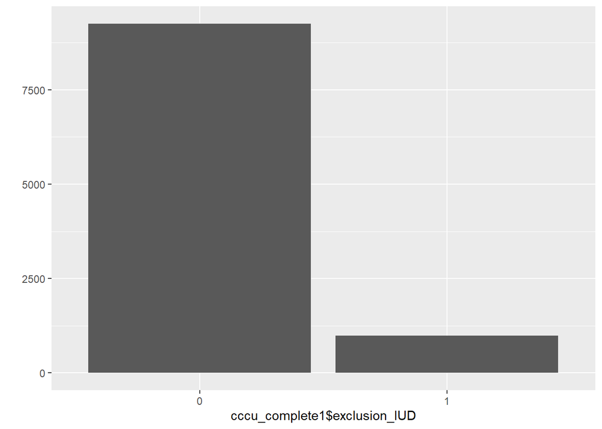

```r
cccu_complete1$exclusion_IUD<- as.factor(cccu_complete1$exclusion_IUD)
qplot(cccu_complete1$exclusion_IUD)
```

```r
x = cccu_complete1 %>%
  select(IUD, hc, exclusion_IUD)



#IUD_next & non-hormonal

table(cccu_complete1$hc_next)
```

```
##
##     non_hc         hc IUD&non_hc
##       3918       2812        717
```

```r
cccu_complete1 <- cccu_complete1 %>%
 mutate(exclusion_IUD_next = ifelse(is.na(hc_next), 0,
                                    ifelse(hc_next == "non_hc" | hc_next == "hc", 0,
                                           ifelse(hc_next == "IUD&non_hc", 1, NA))))

table(cccu_complete1$exclusion_IUD_next)
```

```
##
##    0    1
## 9522  717
```

```r
table(is.na(cccu_complete1$exclusion_IUD_next))
```

```
##
## FALSE
## 10239
```

```r
table(cccu_complete1$exclusion_IUD_next)
```

```
##
##    0    1
## 9522  717
```

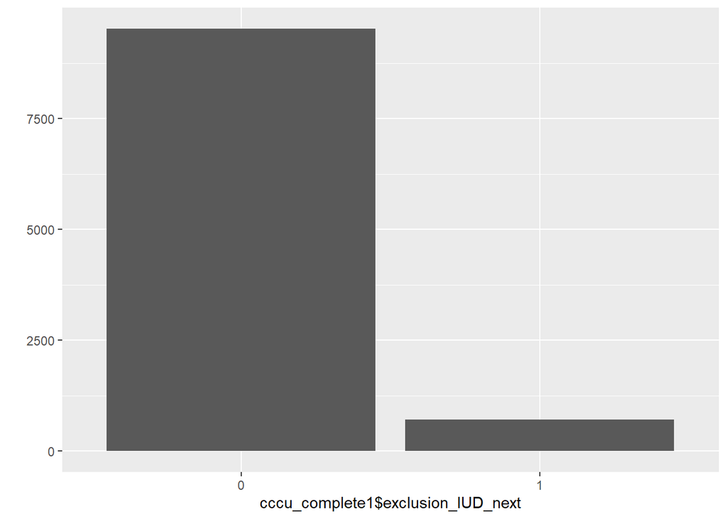

```r
cccu_complete1$exclusion_IUD_next<- as.factor(cccu_complete1$exclusion_IUD_next)
qplot(cccu_complete1$exclusion_IUD_next) #NA (missings) should be removed when excluding for missigness in hc or switch
```

```r
x = cccu_complete1 %>%
  select(CASEID, WAVE, IUD_next, hc_next, exclusion_IUD_next)
```

#column for complete exclusion process of main analysis

```r
#create column for complete exclusion process
cccu_complete1 <- cccu_complete1 %>% mutate(exclusion_complete = as.factor(ifelse(exclusion_missing_predHC == 1 | exclusion_missing_pred_contra_satis ==1 | exclusion_missing_pred_sex_freq ==1 | exclusion_missing_pred_sex_sat ==1 | exclusion_missing_selection ==1 | exclusion_missing_outc_switch ==1 | exclusion_used_EC ==1| exclusion_IUD ==1 | exclusion_IUD_next ==1, 1, 0)))
```

## 4.8 Subanalyses Duration

### 4.8.1 non-hormonal contra

```r
table(cccu_complete1$hc)
```

```
##
##         hc     non_hc IUD&non_hc
##       3965       5282        992
```

```r
cccu_complete1 <- cccu_complete1 %>%
 mutate(exclusion_used_non_hc= ifelse(hc == "non_hc", 1,0))

table(cccu_complete1$exclusion_used_non_hc)
```

```
##
##    0    1
## 4957 5282
```

```r
table(is.na(cccu_complete1$exclusion_used_non_hc))
```

```
##
## FALSE
## 10239
```

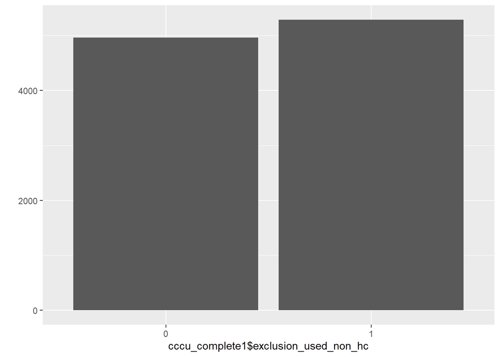

```r
cccu_complete1$exclusion_used_non_hc<- as.factor(cccu_complete1$exclusion_used_non_hc)
qplot(cccu_complete1$exclusion_used_non_hc)
```

### 4.8.2 unknow duration

```r
table(cccu_complete1$hc_dur)
```

```
##
##   0   1   2   3   4   5   6   7   8   9  10  11  12  13  14  15  16  17  18  19
##  42 187 216 209 179 162 251 205 244 222 221 180 196 157 178 173 152 120 130  83
##  20  21  22  23  24  25  26  27  28  29  30  31  32  33  34  35  37  38  40  41
##  95  79  71  49  39  24  21  18   7   5   6   4   6   1   1   2   2   2   1   1
```

```r
table(is.na(cccu_complete1$hc_dur))
```

```
##
## FALSE  TRUE
##  3941  6298
```

```r
crosstabs( ~ is.na(hc_dur) + sex_inlast30days, data = cccu_complete1)
```

```
##              sex_inlast30days
## is.na(hc_dur)   No  Yes
##         FALSE  732 3185
##         TRUE  1494 4753
```

```r
cccu_complete1 <- cccu_complete1 %>%
 mutate(exclusion_missing_pred_hc_dur= ifelse(is.na(hc_dur), 1, 0))

table(cccu_complete1$exclusion_missing_pred_hc_dur)
```

```
##
##    0    1
## 3941 6298
```

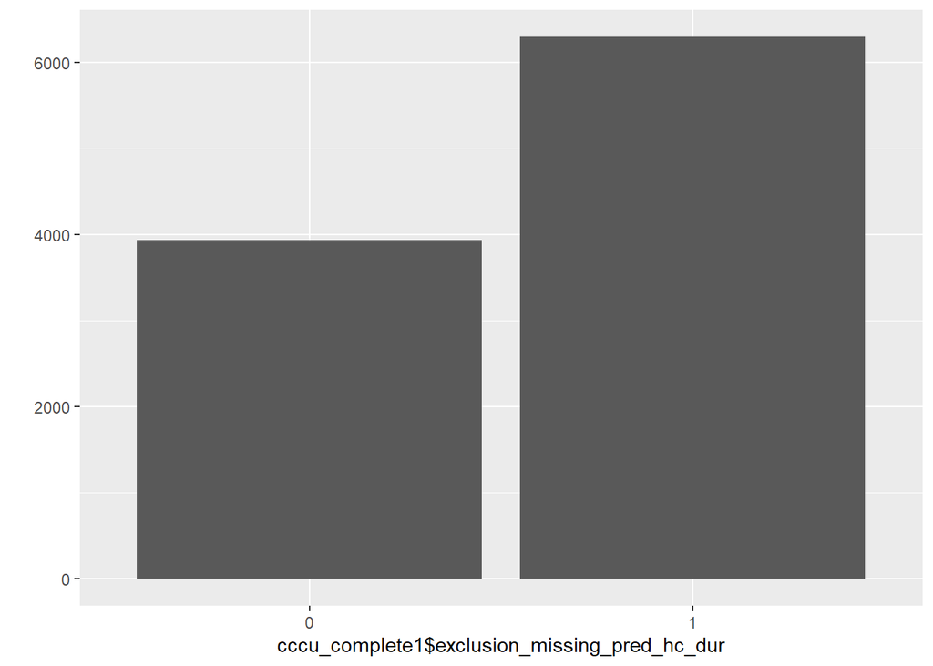

```r
cccu_complete1$exclusion_missing_pred_hc_dur<- as.factor(cccu_complete1$exclusion_missing_pred_hc_dur)
qplot(cccu_complete1$exclusion_missing_pred_hc_dur)
```

```r
x = cccu_complete1 %>%
  select(hc_dur, exclusion_missing_pred_hc_dur)
```

## 4.9 Robustness analyses

### 4.9.1. No sex

```r
table(cccu_complete1$sex_inlast30days)#no sex in last 30 days
```

```
##
##   No  Yes
## 2226 7938
```

```r
#create column that indicates with 1 = no sex and no contraceptive method used in last 30 days

cccu_complete1 <- cccu_complete1 %>%
  mutate(exclusion_R1 = ifelse(is.na(sex_inlast30days), 0,
                               ifelse(sex_inlast30days == "No", 1,
                                      ifelse(sex_inlast30days == "Yes", 0, NA))))

table(is.na(cccu_complete1$exclusion_R1))
```

```
##
## FALSE
## 10239
```

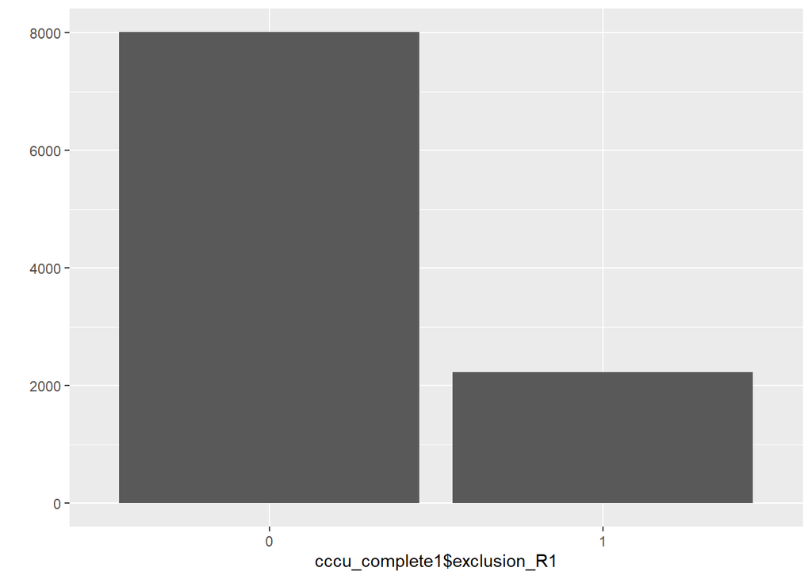

```r
cccu_complete1$exclusion_R1 <-as.factor(cccu_complete1$exclusion_R1)
qplot(cccu_complete1$exclusion_R1)#missingness might be because sex_inlast30days and NOBARRIER can be missing
```

```r
crosstabs(~hc + sex_inlast30days, data =cccu_complete1) #seems to have worked :) :) (see NOBARRIER = (1) Yes, sex_inlast30days = No)
```

```
##             sex_inlast30days
## hc             No  Yes
##   hc          733 3206
##   non_hc     1386 3853
##   IUD&non_hc  107  879
```

```r
crosstabs(~exclusion_R1 + hc + NOBARRIER + sex_inlast30days, data =cccu_complete1) #seems to have worked :) :) (see NOBARRIER = (1) Yes, sex_inlast30days = No)
```

```
## , , NOBARRIER = (0) No, sex_inlast30days = No
##
##             hc
## exclusion_R1   hc non_hc IUD&non_hc
##            0    0      0          0
##            1    0      0          0
##
## , , NOBARRIER = (1) Yes, sex_inlast30days = No
##
##             hc
## exclusion_R1   hc non_hc IUD&non_hc
##            0    0      0          0
##            1    0      0          0
##
## , , NOBARRIER = (0) No, sex_inlast30days = Yes
##
##             hc
## exclusion_R1   hc non_hc IUD&non_hc
##            0 1301   2439        161
##            1    0      0          0
##
## , , NOBARRIER = (1) Yes, sex_inlast30days = Yes
##
##             hc
## exclusion_R1   hc non_hc IUD&non_hc
##            0 1753   1273        677
##            1    0      0          0
```